# Financial Analysis of Field of Studies - Bachelor Degrees in US

##“Financial Analysis of Field of Studies - Bachelor Degrees in US”

This is a complement to the basic statistical analysis that was done based on the data downloaded from the US Department of Education collegescorecard web site.

The US department of education , provides the option to download the data sets used in the tool from the following website:

https://collegescorecard.ed.gov/data/

The analsysis uses the data in the file FieldOfStudyData1516_1617_PP.csv; combining it with Institution information to display a financial comparison of programs. The Earning by Field of study data shows the Median Earnings (and Debt) of Students as of 1 year after graduation for the classes 2015_16 anf 2016_17.

The Data has been pre-processed to show only the records for which Earnings and Tuition information is available. The data has 19,112 records with 14 columns.

```r
FieldofStudy_Earnings_for_rep = read.csv("C:/Users/figue/Documents/Collegeboard_data/June_2020_Update/Field_of_Studies_Earn_rep.csv", stringsAsFactors = FALSE)
dim(FieldofStudy_Earnings_for_rep)
```

```
## [1] 19112    14
```

```r
colnames(FieldofStudy_Earnings_for_rep)
```

```
##  [1] "P_INSTNM"           "P_MAIN"             "P_CIPDESC"
##  [4] "STABBR"             "P_DEBTMEDIAN"       "P_MD_EARN_WNE"
##  [7] "ADM_RATE"           "SAT_AVG"            "Tuition_Average"
## [10] "Tuition_more_110K"  "Debt_payback_YR"    "Tuit_Avg_4Y_Pyback"
## [13] "Tuit_Inc_4Y_Pyback" "Salary_10Y_4Y_Tui"
```

```r
colnames(FieldofStudy_Earnings_for_rep)=c( "INSTNM","MAIN","CIPDESC","STABBR","DEBTMEDIAN","MD_EARN_WNE","ADM_RATE","SAT_AVG","Tuition_Average","Tuition_more_110K","Debt_payback_YR","Tuit_Avg_4Y_Pyback","Tuit_Inc_4Y_Pyback","Salary_10Y_4Y_Tui"    )
colnames(FieldofStudy_Earnings_for_rep)
```

```
##  [1] "INSTNM"             "MAIN"               "CIPDESC"
##  [4] "STABBR"             "DEBTMEDIAN"         "MD_EARN_WNE"
##  [7] "ADM_RATE"           "SAT_AVG"            "Tuition_Average"
## [10] "Tuition_more_110K"  "Debt_payback_YR"    "Tuit_Avg_4Y_Pyback"
## [13] "Tuit_Inc_4Y_Pyback" "Salary_10Y_4Y_Tui"
```

In this analysis, we will review how the words contained in a field of study affect the potential earnings. I will also use SAT scores and Admission rates as predictors of future earnings. This data will be used to create linear regression models that will be discussed later in this document.

The reader might be thinking whether the State where the Institution is located might have something to do with the financial outcome. Prior to moving forward , let’s create a simple linear regression model to test this hypothesis.

```r
lm.Ear.cost = lm(Salary_10Y_4Y_Tui ~ STABBR + ADM_RATE +SAT_AVG , data=FieldofStudy_Earnings_for_rep)

summary(lm.Ear.cost)
```

```
##
## Call:
## lm(formula = Salary_10Y_4Y_Tui ~ STABBR + ADM_RATE + SAT_AVG,
##     data = FieldofStudy_Earnings_for_rep)
##
## Residuals:
##     Min      1Q  Median      3Q     Max
## -366732  -94583  -34529   71266  906776
##
## Coefficients:
##               Estimate Std. Error t value Pr(>|t|)
## (Intercept)  157456.63   65272.08   2.412  0.01586 *
## STABBRAL     -62026.49   63249.37  -0.981  0.32677
## STABBRAR     -60842.11   63737.60  -0.955  0.33981
## STABBRAZ      -8058.04   63454.37  -0.127  0.89895
## STABBRCA     -50476.77   62777.49  -0.804  0.42138
## STABBRCO     -50668.70   63167.51  -0.802  0.42249
## STABBRCT     -50842.62   63574.50  -0.800  0.42388
## STABBRDC     -86936.63   64620.20  -1.345  0.17853
## STABBRDE      -5254.94   66338.91  -0.079  0.93686
## STABBRFL     -60935.43   62917.88  -0.968  0.33281
## STABBRGA     -57586.28   62978.38  -0.914  0.36053
## STABBRHI     -45782.39   64886.14  -0.706  0.48046
## STABBRIA     -34895.85   63212.96  -0.552  0.58093
## STABBRID     -28844.75   64011.22  -0.451  0.65227
## STABBRIL     -37826.35   62884.92  -0.602  0.54750
## STABBRIN     -13346.39   63016.18  -0.212  0.83227
## STABBRKS     -18339.03   64019.61  -0.286  0.77453
## STABBRKY     -50392.42   63252.97  -0.797  0.42565
## STABBRLA     -59552.50   63315.62  -0.941  0.34694
## STABBRMA     -45329.07   62995.61  -0.720  0.47181
## STABBRMD     -45944.01   63403.52  -0.725  0.46869
## STABBRME      -1147.74   65267.90  -0.018  0.98597
## STABBRMI     -18330.39   62891.57  -0.291  0.77070
## STABBRMN     -37030.86   63012.61  -0.588  0.55676
## STABBRMO     -42629.68   63096.83  -0.676  0.49929
## STABBRMS     -67818.46   64019.54  -1.059  0.28946
## STABBRMT     -75598.52   64892.91  -1.165  0.24405
## STABBRNC     -64996.97   62936.53  -1.033  0.30174
## STABBRND      29143.16   64888.56   0.449  0.65335
```

[output cut: 17 more lines]

```
## STABBRVA     -55044.69   63002.44  -0.874  0.38230
## STABBRVT    -100529.85   65631.70  -1.532  0.12561
## STABBRWA     -22841.59   63060.55  -0.362  0.71719
## STABBRWI     -30955.95   62973.13  -0.492  0.62303
## STABBRWV     -24484.23   63855.26  -0.383  0.70140
## STABBRWY     -36198.63   67847.64  -0.534  0.59368
## ADM_RATE     -26235.22    8318.74  -3.154  0.00161 **
## SAT_AVG         182.20      12.29  14.821  < 2e-16 ***
## ---
## Signif. codes:  0 '***' 0.001 '**' 0.01 '*' 0.05 '.' 0.1 ' ' 1
##
## Residual standard error: 140000 on 15612 degrees of freedom
##   (3446 observations deleted due to missingness)
## Multiple R-squared:  0.04097,    Adjusted R-squared:  0.03771
## F-statistic: 12.58 on 53 and 15612 DF,  p-value: < 2.2e-16
```

Since Puerto Rico is relevant , I will add a variable to keep track of this Territory and I will avoid using the feature STABBR which contains the values for all states.

```r
FieldofStudy_Earnings_for_rep$Puerto_Rico = ifelse(FieldofStudy_Earnings_for_rep$STABBR=="PR",1,0)
```

Let’s continue by splitting the description of the fields of study into individual words. The tm package in r is very helpful to complete this. There are many different words in the descriptions of the fields of study, it is important to keep the ones that repeat the most , those are the most relevant.

```r
library(tm)
#CIPDESC is the description . I would like to analyze

docs = FieldofStudy_Earnings_for_rep$CIPDESC

#Vector Source can create a Corpuse from the vector

Field.Corpus = VCorpus(VectorSource(docs))

#Transformations to normalize data, remove common words and punctuation

#Conver to lower case

Field.Corpus = tm_map(Field.Corpus, content_transformer(tolower))

#there are still dots
#remove stop words

Field.Corpus = tm_map(Field.Corpus, removeWords, stopwords("english"))

#punctuation

Field.Corpus = tm_map(Field.Corpus, removePunctuation)

#Document term matrix

Field.matrix = DocumentTermMatrix(Field.Corpus)

# Convert to normal matrix in r
r.field.matrix = as.matrix(Field.matrix)

#Add the description names to

rownames(r.field.matrix) = FieldofStudy_Earnings_for_rep$CIPDESC

#find most commong words
count_of_word = apply(r.field.matrix,2,sum)

count_of_word = count_of_word[order(count_of_word,decreasing=TRUE)]

#the most common is general 3,456 times

#there a total of 380 words. How many repeat more than 200 times in degreese

sum(count_of_word>200)
```

```
## [1] 70
```

```r
# 72. Keep those 72


count_of_word  = count_of_word [count_of_word>200]

#now just keep those columns in the r.field.matrix

r.field.matrix.red = r.field.matrix[,names(count_of_word)]

r.field.matrix.red = cbind(r.field.matrix.red, FieldofStudy_Earnings_for_rep[,c("Puerto_Rico","ADM_RATE","SAT_AVG","Salary_10Y_4Y_Tui")])
#change state to Factor
r.field.matrix.red$Puerto_Rico = as.factor(r.field.matrix.red$Puerto_Rico)

colnames(r.field.matrix.red)
```

```
##  [1] "general"                 "nursing"
##  [3] "management"              "administration"
##  [5] "services"                "studies"
##  [7] "engineering"             "sciences"
##  [9] "arts"                    "business"
## [11] "operations"              "health"
## [13] "education"               "related"
## [15] "research"                "development"
## [17] "clinical"                "psychology"
## [19] "communication"           "professional"
## [21] "specific"                "teacher"
## [23] "biology"                 "computer"
## [25] "registered"              "science"
## [27] "methods"                 "media"
## [29] "corrections"             "criminal"
```

[output cut: 22 more lines]

Several of these words are part of a single Field of Study description so they will be perfectly correlated. This is not benefitial for a linear regression (and in general for any machine learning algorithm). The following code removes the fields that are perfectly correlated.

```r
# Using  Apply I can find the counts that are identical across words. By removing duplicates a eliminate perfect correlation
# and remove the columns with duplicated numbers r keep the ones that are unique
colnames(r.field.matrix.red[,c(1:70)])[!duplicated(apply(r.field.matrix.red[,c(1:70)],2,sum))]
```

```
##  [1] "general"                 "nursing"
##  [3] "management"              "administration"
##  [5] "services"                "studies"
##  [7] "engineering"             "sciences"
##  [9] "arts"                    "business"
## [11] "operations"              "health"
## [13] "education"               "related"
## [15] "research"                "development"
## [17] "clinical"                "psychology"
## [19] "communication"           "professional"
## [21] "specific"                "biology"
## [23] "computer"                "registered"
## [25] "science"                 "methods"
## [27] "media"                   "corrections"
## [29] "accounting"              "levels"
```

[output cut: 16 more lines]

```r
r.field.matrix.red_nocor = r.field.matrix.red[,c(colnames(r.field.matrix.red[,c(1:70)])[!duplicated(apply(r.field.matrix.red[,c(1:70)],2,sum))],"Puerto_Rico","ADM_RATE","SAT_AVG","Salary_10Y_4Y_Tui")]

#Do a linear regression

lm.Ear.cost4 = lm(Salary_10Y_4Y_Tui ~ . , data=r.field.matrix.red_nocor)
summary(lm.Ear.cost4)
```

```
##
## Call:
## lm(formula = Salary_10Y_4Y_Tui ~ ., data = r.field.matrix.red_nocor)
##
## Residuals:
##     Min      1Q  Median      3Q     Max
## -354300  -43022   -1441   38075  841700
##
## Coefficients: (1 not defined because of singularities)
##                           Estimate Std. Error t value Pr(>|t|)
## (Intercept)              1.518e+05  9.873e+03  15.374  < 2e-16 ***
## general                 -3.823e+03  3.470e+03  -1.102 0.270669
## nursing                  2.130e+05  2.624e+04   8.117 5.14e-16 ***
## management               4.039e+04  5.302e+03   7.618 2.73e-14 ***
## administration           4.194e+04  7.788e+03   5.385 7.35e-08 ***
## services                -1.249e+04  5.108e+03  -2.445 0.014496 *
## studies                 -3.323e+04  3.702e+03  -8.976  < 2e-16 ***
## engineering              2.375e+05  3.301e+03  71.941  < 2e-16 ***
## sciences                -1.980e+04  3.985e+03  -4.969 6.81e-07 ***
## arts                    -1.374e+05  4.879e+03 -28.153  < 2e-16 ***
## business                 2.384e+04  6.515e+03   3.660 0.000253 ***
## operations              -3.644e+04  7.536e+03  -4.835 1.34e-06 ***
## health                  -9.034e+03  6.023e+03  -1.500 0.133657
## education                8.639e+03  6.165e+03   1.401 0.161191
## related                 -1.608e+04  6.094e+03  -2.639 0.008328 **
## research                -2.217e+04  9.780e+03  -2.267 0.023426 *
## development             -4.963e+04  1.371e+04  -3.619 0.000296 ***
## clinical                -2.173e+04  9.508e+03  -2.285 0.022301 *
## psychology              -6.302e+04  4.610e+03 -13.670  < 2e-16 ***
## communication           -3.976e+04  5.659e+03  -7.025 2.23e-12 ***
## professional             4.473e+04  5.661e+04   0.790 0.429448
## specific                 2.219e+03  5.963e+04   0.037 0.970310
## biology                 -6.653e+04  4.210e+03 -15.802  < 2e-16 ***
## computer                 1.358e+05  5.164e+03  26.297  < 2e-16 ***
## registered              -5.651e+05  1.061e+05  -5.327 1.01e-07 ***
## science                  1.346e+05  6.467e+03  20.809  < 2e-16 ***
## methods                  1.374e+05  1.195e+04  11.504  < 2e-16 ***
## media                    3.510e+04  7.028e+03   4.994 5.98e-07 ***
## corrections             -1.080e+04  4.372e+03  -2.471 0.013468 *
## accounting               1.623e+05  8.186e+03  19.826  < 2e-16 ***
```

[output cut: 27 more lines]

```
## relations               -1.794e+04  8.225e+03  -2.181 0.029226 *
## technologiestechnicians  5.019e+04  7.209e+03   6.962 3.50e-12 ***
## businesscommerce         6.779e+04  7.235e+03   9.370  < 2e-16 ***
## medical                  5.233e+04  1.111e+04   4.712 2.48e-06 ***
## electronics              1.259e+05  1.984e+04   6.347 2.26e-10 ***
## Puerto_Rico1            -1.726e+05  3.224e+04  -5.353 8.76e-08 ***
## ADM_RATE                -2.534e+04  3.866e+03  -6.554 5.77e-11 ***
## SAT_AVG                  1.153e+02  6.733e+00  17.131  < 2e-16 ***
## ---
## Signif. codes:  0 '***' 0.001 '**' 0.01 '*' 0.05 '.' 0.1 ' ' 1
##
## Residual standard error: 78690 on 15602 degrees of freedom
##   (3446 observations deleted due to missingness)
## Multiple R-squared:  0.6974, Adjusted R-squared:  0.6961
## F-statistic: 570.6 on 63 and 15602 DF,  p-value: < 2.2e-16
```

```r
#areas seem to be highly correlated.Yields singularities Remove.
```

The word areas seems to be correlated to other variables. There are other words that are highly correlated to ohters that should be removed. In the next lines of code, I check for the correlated variables and remove a few of them manually. In addition to this, I will remove words that are not statistically significant. After this is done a new linear regression is created.

```r
#check correlated variables
#this returns the pairs.
#I need to keep only the top
Corr.m.9 = which(cor(r.field.matrix.red[,1:70])>.9 , arr.ind=TRUE)
#remove diagonal

Corr.m.9=Corr.m.9[!(Corr.m.9[,"row"] == Corr.m.9[,"col"]),]

#bind names that are too correlated

corr_pairs = cbind(rownames(cor(r.field.matrix.red[,1:70]))[Corr.m.9[,"row"]],colnames(cor(r.field.matrix.red[,1:70]))[Corr.m.9[,"col"]])

# Choose which word is more relevant or better describes a degree. The other words will have to be removed
#start with nursing
#for example this is highly correlated to clinical and registerd
#those should be removed
words_remove = corr_pairs[corr_pairs[,1]=="nursing",2]
#for keeping track remove from corr_pairs

corr_pairs=corr_pairs[!(corr_pairs[,1] %in% words_remove),]
#now look fo teacher. Development, professional, specific
words_remove = c(words_remove,corr_pairs[corr_pairs[,1]=="teacher",2])
#update pairs
corr_pairs=corr_pairs[!(corr_pairs[,1] %in% words_remove),]

#justice
words_remove = c(words_remove,corr_pairs[corr_pairs[,1]=="justice",2])
#update pairs
corr_pairs=corr_pairs[!(corr_pairs[,1] %in% words_remove),]

#methods
words_remove = c(words_remove,corr_pairs[corr_pairs[,1]=="methods",2])
#update pairs
corr_pairs=corr_pairs[!(corr_pairs[,1] %in% words_remove),]

#literature
words_remove = c(words_remove,corr_pairs[corr_pairs[,1]=="literature",2])
#update pairs
corr_pairs=corr_pairs[!(corr_pairs[,1] %in% words_remove),]

#educationfitness
words_remove = c(words_remove,corr_pairs[corr_pairs[,1]=="educationfitness",2])
#update pairs
corr_pairs=corr_pairs[!(corr_pairs[,1] %in% words_remove),]

#humanities
words_remove = c(words_remove,corr_pairs[corr_pairs[,1]=="humanities",2])
#update pairs
corr_pairs=corr_pairs[!(corr_pairs[,1] %in% words_remove),]

#government
words_remove = c(words_remove,corr_pairs[corr_pairs[,1]=="government",2])
#update pairs
corr_pairs=corr_pairs[!(corr_pairs[,1] %in% words_remove),]

#fine
words_remove = c(words_remove,corr_pairs[corr_pairs[,1]=="fine",2])
#update pairs
corr_pairs=corr_pairs[!(corr_pairs[,1] %in% words_remove),]

#finance
words_remove = c(words_remove,corr_pairs[corr_pairs[,1]=="finance",2])
#update pairs
corr_pairs=corr_pairs[!(corr_pairs[,1] %in% words_remove),]

#subject
words_remove = c(words_remove,corr_pairs[corr_pairs[,1]=="subject",2])
#update pairs
corr_pairs=corr_pairs[!(corr_pairs[,1] %in% words_remove),]

#electronics
words_remove = c(words_remove,corr_pairs[corr_pairs[,1]=="electronics",2])
#update pairs
corr_pairs=corr_pairs[!(corr_pairs[,1] %in% words_remove),]

#medical
words_remove = c(words_remove,corr_pairs[corr_pairs[,1]=="medical",2])
#update pairs
corr_pairs=corr_pairs[!(corr_pairs[,1] %in% words_remove),]

#remove all fields that correspond to words that are highly correlated

r.field.matrix.red_nocor = r.field.matrix.red_nocor[,!(colnames(r.field.matrix.red_nocor) %in% words_remove)]


lm.Ear.cost4 = lm(Salary_10Y_4Y_Tui ~ . , data=r.field.matrix.red_nocor)

#I will remove coefficients that are not significant more than .05

lm.Ear.cost4$coefficients[2]
```

```
##   general
## -1721.551
```

```r
# retrieve the names of the variables that are significan
names.to.keep = names(summary(lm.Ear.cost4)[["coefficients"]][,"Pr(>|t|)"])[summary(lm.Ear.cost4)[["coefficients"]][,"Pr(>|t|)"]<.05]

#except for intercept these are names in r.field.matrix.red_nocor. Remember that we also have to keep Salary_10Y_4Y_Tui
#For some reason Puerto_Rico1 is presented as a coefficient and not Puerto Rico
r.field.matrix.red_nocor.sig = r.field.matrix.red_nocor[,c(colnames(r.field.matrix.red_nocor)[colnames(r.field.matrix.red_nocor) %in% names.to.keep], "Puerto_Rico","Salary_10Y_4Y_Tui")]

lm.Ear.cost5 = lm(Salary_10Y_4Y_Tui ~ . , data=r.field.matrix.red_nocor.sig)

summary(lm.Ear.cost5)
```

```
##
## Call:
## lm(formula = Salary_10Y_4Y_Tui ~ ., data = r.field.matrix.red_nocor.sig)
##
## Residuals:
##     Min      1Q  Median      3Q     Max
## -378055  -43433   -1870   38364  853162
##
## Coefficients:
##                           Estimate Std. Error t value Pr(>|t|)
## (Intercept)              1.442e+05  9.684e+03  14.891  < 2e-16 ***
## nursing                  7.122e+04  2.871e+03  24.806  < 2e-16 ***
## management               6.797e+04  4.646e+03  14.630  < 2e-16 ***
## administration           2.278e+04  7.324e+03   3.110  0.00187 **
## services                -2.104e+04  4.728e+03  -4.449 8.67e-06 ***
## studies                 -3.287e+04  3.436e+03  -9.565  < 2e-16 ***
## engineering              2.382e+05  3.162e+03  75.330  < 2e-16 ***
## sciences                -9.661e+03  3.451e+03  -2.800  0.00512 **
## arts                    -1.371e+05  4.801e+03 -28.548  < 2e-16 ***
## business                 1.524e+04  6.422e+03   2.373  0.01767 *
## operations              -3.349e+04  7.449e+03  -4.496 6.96e-06 ***
## health                  -1.599e+04  5.170e+03  -3.092  0.00199 **
## related                 -2.765e+04  5.286e+03  -5.232 1.70e-07 ***
## research                -1.987e+04  8.941e+03  -2.222  0.02630 *
## psychology              -6.475e+04  3.243e+03 -19.964  < 2e-16 ***
## communication           -3.529e+04  5.514e+03  -6.401 1.59e-10 ***
## biology                 -6.746e+04  3.260e+03 -20.691  < 2e-16 ***
## computer                 1.373e+05  5.134e+03  26.741  < 2e-16 ***
## science                  1.331e+05  6.417e+03  20.740  < 2e-16 ***
## methods                  2.159e+04  3.748e+03   5.760 8.57e-09 ***
## media                    3.174e+04  6.976e+03   4.551 5.39e-06 ***
## accounting               1.848e+05  6.973e+03  26.500  < 2e-16 ***
## information              1.352e+05  5.403e+03  25.018  < 2e-16 ***
## marketing                5.892e+04  4.290e+03  13.732  < 2e-16 ***
## literature              -7.557e+04  4.186e+03 -18.053  < 2e-16 ***
## applied                  5.742e+04  8.328e+03   6.894 5.61e-12 ***
## social                  -3.875e+04  8.725e+03  -4.441 9.03e-06 ***
## educationfitness        -3.850e+04  6.663e+03  -5.777 7.74e-09 ***
## government              -1.546e+05  7.623e+03 -20.285  < 2e-16 ***
## sociology               -4.448e+04  4.600e+03  -9.670  < 2e-16 ***
```

[output cut: 12 more lines]

```
## relations               -1.855e+04  7.892e+03  -2.351  0.01875 *
## technologiestechnicians  4.898e+04  6.698e+03   7.312 2.76e-13 ***
## businesscommerce         6.638e+04  6.384e+03  10.399  < 2e-16 ***
## medical                  6.893e+04  1.037e+04   6.644 3.15e-11 ***
## electronics              8.484e+04  6.358e+03  13.344  < 2e-16 ***
## ADM_RATE                -2.491e+04  3.881e+03  -6.419 1.41e-10 ***
## SAT_AVG                  1.196e+02  6.683e+00  17.899  < 2e-16 ***
## Puerto_Rico1            -1.746e+05  3.238e+04  -5.391 7.11e-08 ***
## ---
## Signif. codes:  0 '***' 0.001 '**' 0.01 '*' 0.05 '.' 0.1 ' ' 1
##
## Residual standard error: 79100 on 15616 degrees of freedom
##   (3446 observations deleted due to missingness)
## Multiple R-squared:  0.6939, Adjusted R-squared:  0.693
## F-statistic: 722.5 on 49 and 15616 DF,  p-value: < 2.2e-16
```

```r
write.csv(r.field.matrix.red_nocor.sig,"C:/Users/figue/Documents/Collegeboard_data/June_2020_Update/Field_of_Studies_Earn_rep_matrix.csv")
```

In this last linear regression all of the features are statistically significant.These features explain close to 70% of the variance in “Net Operating Income” after 10 years (R - squared 0.6939). A few things that can be pointed out are that students graduating in Puerto Rico should expect to earn $174,600 less over 10 years after graduation (if they keep the same 1st year salary) compared to students graduating from Institutions in one of the 50 States in the US.

SAT scores and admission rates matter in terms of earnings , probably because they are factors associated to prestigious Institutions. An extra point in the SAT AVG Score of the Universty translates into US 119 in additional earnings over 10 years. To put it in perspective, the student graduating from an institution with an Average SAT score of 1,500 versus an Institution with an Average SAT Score of 1,100 will earn on average about US47,600 more over 10 years . The Admission rate have a similar impact but in the opposite direction, for every drop of one percentage point (0.01) of the admission rate for the institution the expectation would be to earn about US$249 more over 10 years.

Next, I show the density functions for SAT Scores and Admission Rates.

```r
#For the calculation of the density function, I will start with the original data.
#Since the SAT score and admission rate is by Institution then this information repeats for the Fields of Studies offered at the
#College/University. It is required to remove duplicates

#create Dataframe with required fields
SAT_ADM_INST = FieldofStudy_Earnings_for_rep[,c("INSTNM","ADM_RATE","SAT_AVG")]
#Eliminate duplicates
SAT_ADM_INST= SAT_ADM_INST[!(duplicated(SAT_ADM_INST)),]

# Remove NAs
SAT_ADM_INST=na.omit(SAT_ADM_INST)

library(ggplot2)
#Create density chart for SAT first

dens <- density(SAT_ADM_INST$SAT_AVG)
df <- data.frame(x=dens$x, y=dens$y)

#want to find what is the percentile corresponding to an average score of 1500
percentile=ecdf(SAT_ADM_INST$SAT_AVG)
prob_1500 = round(percentile(1500),4)
prob_1500
```

```
## [1] 0.9868
```

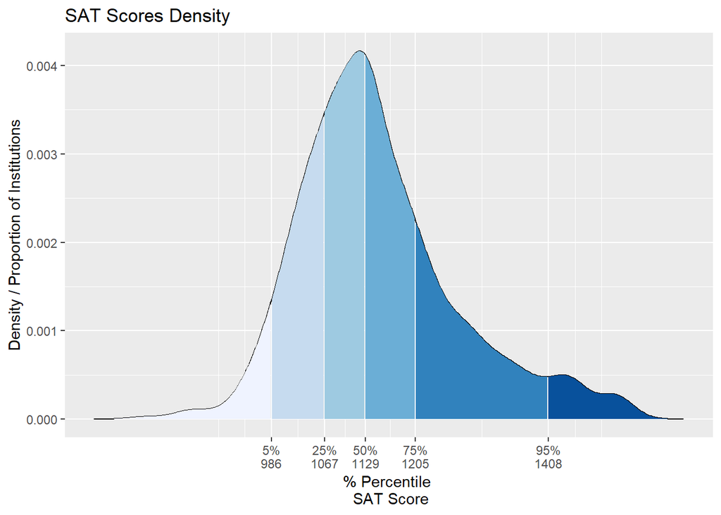

```r
probs <- c(0.05, 0.25, 0.5, 0.75, 0.95)
quantiles <- quantile(SAT_ADM_INST$SAT_AVG, prob=probs)
df$quant <- factor(findInterval(df$x,quantiles))

quantile_SAT = paste(round(quantiles,0))
label_quants = paste(names(quantiles),quantile_SAT,sep="\n")

ggplot(df, aes(x,y)) + geom_line() + geom_ribbon(aes(ymin=0, ymax=y, fill=quant)) + scale_x_continuous(breaks=quantiles, labels = label_quants ) + scale_fill_brewer(guide="none") + ggtitle("SAT Scores Density") + xlab("% Percentile \n SAT Score") + ylab("Density / Proportion of Institutions")
```

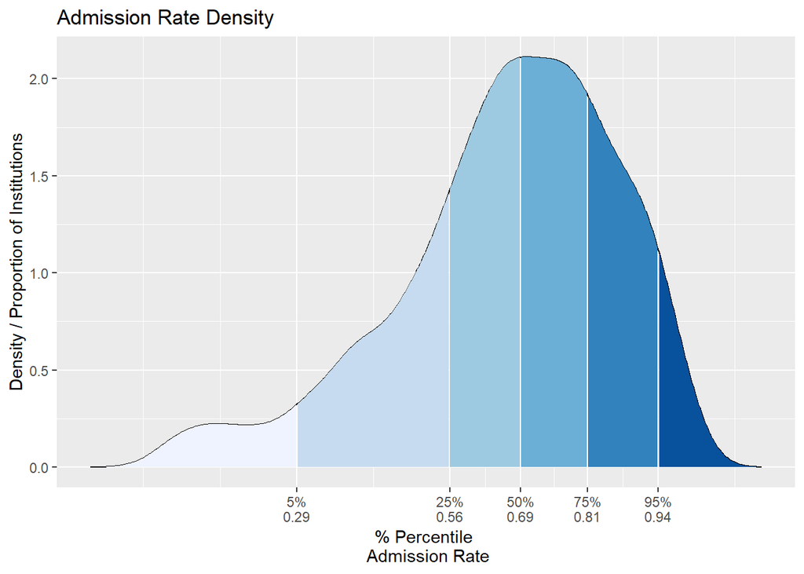

```r
#Create density for admission rate


dens <- density(SAT_ADM_INST$ADM_RATE)
df <- data.frame(x=dens$x, y=dens$y)
probs <- c(0.05, 0.25, 0.5, 0.75, 0.95)
quantiles <- quantile(SAT_ADM_INST$ADM_RATE, prob=probs)
df$quant <- factor(findInterval(df$x,quantiles))

quantile_ADM = paste(round(quantiles,2))
label_quants = paste(names(quantiles),quantile_ADM,sep="\n")

ggplot(df, aes(x,y)) + geom_line() + geom_ribbon(aes(ymin=0, ymax=y, fill=quant)) + scale_x_continuous(breaks=quantiles, labels = label_quants ) + scale_fill_brewer(guide="none") + ggtitle("Admission Rate Density") + xlab("% Percentile \n Admission Rate") + ylab("Density / Proportion of Institutions")
```

The next code will create divergence charts by using the words that were taken into consideration as factors for the Linear regreassion that was calculated earlier.

```r
library(scales)
#This contains all of the estimated coefficients
summary(lm.Ear.cost5)[["coefficients"]][,"Estimate"]
```

```
##             (Intercept)                 nursing              management
##             144196.6215              71219.8558              67974.2427
##          administration                services                 studies
##              22781.5258             -21039.4280             -32867.9345
##             engineering                sciences                    arts
##             238227.0443              -9661.2821            -137068.2139
##                business              operations                  health
##              15238.7270             -33494.7240             -15985.3921
##                 related                research              psychology
##             -27654.1088             -19865.5417             -64753.6328
##           communication                 biology                computer
##             -35289.7534             -67456.2091             137288.1338
##                 science                 methods                   media
##             133098.9611              21586.6756              31743.4349
##              accounting             information               marketing
##             184797.4504             135163.1758              58916.7645
##              literature                 applied                  social
##             -75567.3733              57419.0636             -38745.0173
##        educationfitness              government               sociology
##             -38495.2005            -154629.9066             -44483.7079
##              humanities                   human               economics
##             149545.2750              35613.6926              98250.0594
##               resources             professions                 finance
##             -22449.8852              51182.7012              87389.6441
##                    fine                 history              mechanical
##              38450.4673             -53638.8780              25244.7982
##                    work                  allied                  design
##              22829.8671             133656.0814              64773.1072
##               relations technologiestechnicians        businesscommerce
##             -18550.5914              48976.9957              66383.4528
##                 medical             electronics                ADM_RATE
##              68927.4083              84844.1323             -24913.3042
##                 SAT_AVG            Puerto_Rico1
##                119.6194            -174555.3252
```

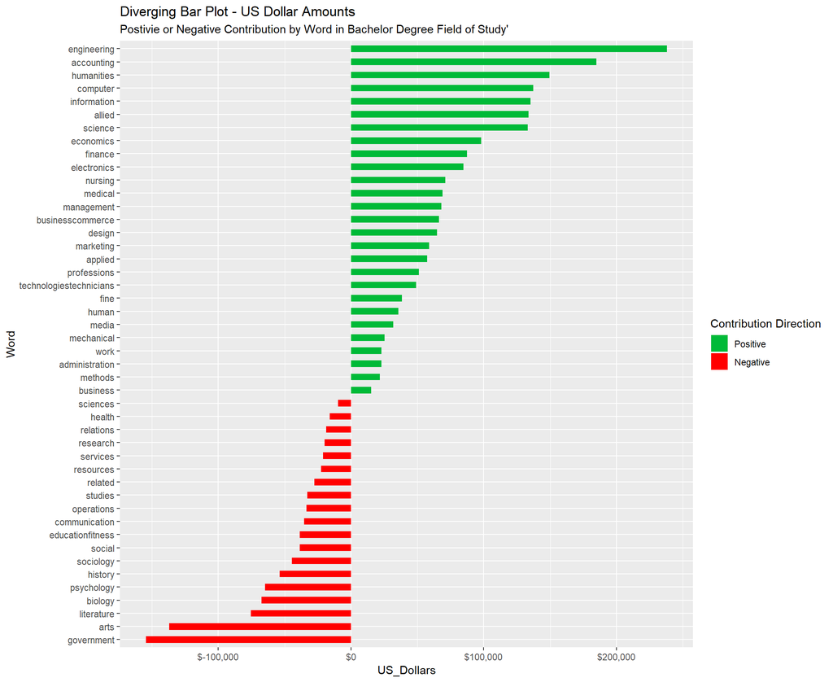

```r
#will keep only the featuers for words in Fiedls of Study

Word_Fields = summary(lm.Ear.cost5)[["coefficients"]][,"Estimate"][2:47]
# Negative or Positive contribution
Contribution = ifelse(Word_Fields>0, "Positive", "Negative")
#bind
Word_Fields=as.data.frame(cbind(Word_Fields,Contribution), stringsAsFactors=FALSE)
Word_Fields$Word = rownames(Word_Fields)

#update column Names

colnames(Word_Fields)=c("US_Dollars","Contribution_Direction","Word")

Word_Fields$US_Dollars = as.numeric(Word_Fields$US_Dollars)
#round US dollars

#have to correct the sorting.....
Word_Fields$US_Dollars = round(Word_Fields$US_Dollars,0)
#change words and Contribution to factors
Word_Fields$Word = as.factor(Word_Fields$Word)
Word_Fields$Contribution_Direction = as.factor(Word_Fields$Contribution_Direction)
#sort by dollars

Word_Fields=Word_Fields[order(Word_Fields$US_Dollars,decreasing = FALSE),]
#this is necenssary to conver Word to factor and for it to be sorted correctly

Word_Fields$Word <- factor(Word_Fields$Word, levels = Word_Fields$Word)


Word_Fields$Contribution_Direction <- factor(Word_Fields$Contribution_Direction, levels(Word_Fields$Contribution_Direction)[c(2,1)])

p = ggplot(Word_Fields, aes(x=Word, y=US_Dollars, label=Word)) +
   geom_bar(stat='identity', aes(fill=Contribution_Direction), width=.5) +
   scale_fill_manual(name="Contribution Direction",
                    labels = c("Positive", "Negative"),
                    values = c("Positive"="#00ba38", "Negative"="red")) +  scale_y_continuous(labels=dollar_format()) +
   labs(subtitle="Postivie or Negative Contribution by Word in Bachelor Degree Field of Study'",
         title= "Diverging Bar Plot - US Dollar Amounts") +
   coord_flip()

p
```

The previous chart provides a quick way to identify the words in the Field of Studies that yield a better return over 10 years. As an example, combining engineering with computer or electronics predicts a better financial outcome by a large margin. On the negative side of the chart, there are a few surprises like Biology. It is likely that students in this type of career delay their higher incomes because they pursue Medicine or Veterinary programs after their undergraduate degrees. As for the word government that seems to be the one that affects the results more negatively, this is combined with political science in the name of the field of study so the net result is around 0.

Eventhough , this is probably a good guideline to make a decision; this should be combined with information about the range of incomes (variance) for a particular field of study. If the variance is large, then it becomes more important to research the best schools for that program to maximize the potential income after graduation.

```r
library(plotly)
#I will focus on Finance and Financial Management Services. and Economics
Eco_Business = FieldofStudy_Earnings_for_rep[FieldofStudy_Earnings_for_rep$CIPDESC=="Finance and Financial Management Services." | FieldofStudy_Earnings_for_rep$CIPDESC=="Economics.",c("CIPDESC","ADM_RATE","SAT_AVG","Salary_10Y_4Y_Tui")]

# replace Finance and Finacial Management... with Financeand Economics. with Economics

Eco_Business$CIPDESC = ifelse(Eco_Business$CIPDESC=="Economics.","Economics","Finance")

#change to factor
Eco_Business$CIPDESC = as.factor(Eco_Business$CIPDESC)
#omit any NAs

Eco_Business=na.omit(Eco_Business)

fig <- plot_ly(Eco_Business, x = ~ADM_RATE, y = ~SAT_AVG, z = ~Salary_10Y_4Y_Tui, color = ~CIPDESC, colors = c('#BF382A', '#0C4B8E'))
fig <- fig %>% add_markers()
fig <- fig %>% layout(scene = list(xaxis = list(title = 'Admission Rate'),
                     yaxis = list(title = 'SAT Avg Score'),
                     zaxis = list(title = 'Net Income over 10Y')))

fig
```

[interactive chart not shown]

The Scatter Plot shows how there is more variance for a degree in Economics (In red). A student by choosing the right Institution(s) is likely to maximize the level of income after graduation. As for the degree in Finance, eventhough there is an outlier, the expected income for the majority of the programs is clustered. In short there is more value in looking for good institutions offering Economics majors than Finance majors. For Finance Majors there are only 3 Instutions with top earnings after graduation as for Economics there are about ~20.

#Conclusions

The following are takeaways from this and the previous statistical analysis.

1. The most significant predictor of earnings after graduating from college is the Field of Study chosen and not the Institution from which the student graduates.
2. Puerto Rico is the only territory / State, where the graduates should expect to earn less after graduation, statistically speaking. To address this situation the students in this territory should plan to move to one of the 50 states, after graduation, to increase their earning potential substantially.
3. SAT Scores and Instituion Admission rates predict less than 4% of the variance of the earnings.
4. Once a Field of Study is chosen, it makes sense to look for Specific Institutions when there is a high degree of variance in the expected Operating Income. For example studients pursuing careers in Computer Engineering, Computer Science, Economics and Nursing should look into the top institutions in terms of potential operating income.
5. For degress that yield lowest levels of earnings after graduation, it is of the most importance for the students to attend institutions with the lowest possible costs. Student Loans should be avoided as much as possible when pursuing these degrees.

#Additional Work - Create a Net Income Prediction Model

```r
#FieldofStudy_Earnings_for_rep contains all of the records 19112 entries
#r.field.matrix.red_nocor.sig  contaims similar information and the target variable Salary_10Y_4Y_Tui
# 50 variables for a regression so pick from 10 at a time.

library(randomForest)
```

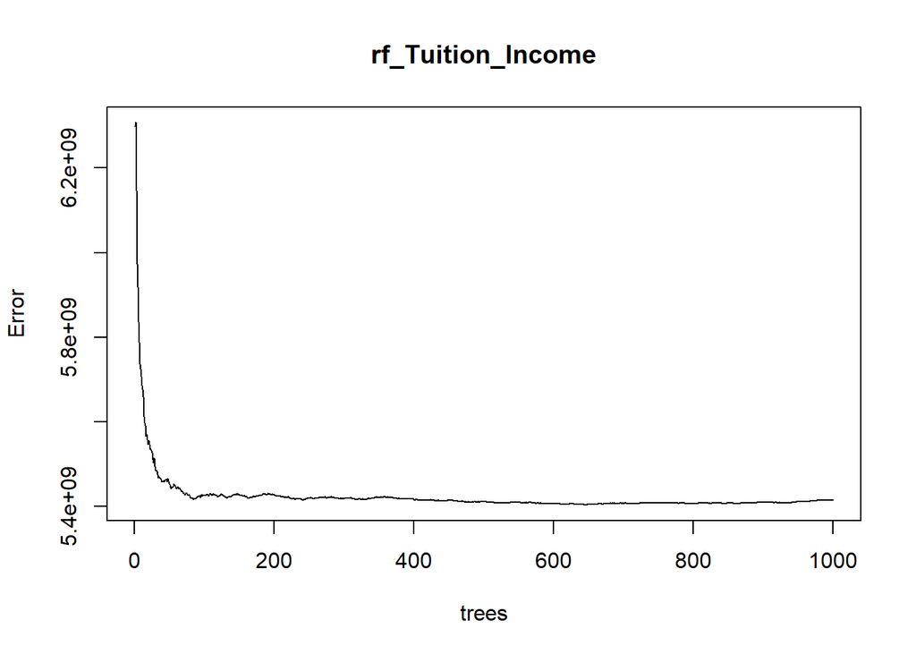

```r
#have to change Target to Numeric from Integrer
r.field.matrix.red_nocor.sig$Salary_10Y_4Y_Tui = as.numeric(r.field.matrix.red_nocor.sig$Salary_10Y_4Y_Tui)
#there are NAs in fields ADM_RATE SAT_AVG
#will remove records in those fields with NAs

r.field.matrix.red_nocor.sig.no.nas = r.field.matrix.red_nocor.sig[!is.na(r.field.matrix.red_nocor.sig$ADM_RATE)  & !is.na(r.field.matrix.red_nocor.sig$SAT_AVG),]

rf_Tuition_Income = randomForest(Salary_10Y_4Y_Tui ~ . , data=r.field.matrix.red_nocor.sig.no.nas, mtry=10 ,ntree=1000,importance=TRUE, keep.forest=TRUE)

plot(rf_Tuition_Income)
```

```r
importance(rf_Tuition_Income)
```

```
##                            %IncMSE IncNodePurity
## nursing                  44.012599  1.956462e+13
## management               69.015576  7.452344e+12
## administration           27.949920  8.786557e+12
## services                 32.839302  3.448568e+12
## studies                  26.654319  2.559177e+12
## engineering             161.456125  7.036217e+13
## sciences                 30.655411  9.932753e+11
## arts                     57.954791  6.539634e+12
## business                 35.807915  1.512845e+12
## operations               21.712528  1.169403e+12
## health                   32.318183  4.992841e+11
## related                  21.111491  1.059517e+12
## research                 26.487502  9.183091e+12
## psychology               46.434674  3.087413e+12
## communication            31.886175  5.799754e+11
## biology                  44.798685  3.037520e+12
## computer                 93.010013  2.720858e+13
## science                  18.349666  1.843315e+12
## methods                  29.324273  4.326594e+11
## media                    20.216390  4.300230e+11
## accounting               63.778053  4.757395e+12
## information              94.040801  9.093795e+12
## marketing                98.291090  1.699196e+12
## literature               53.740429  1.813748e+12
## applied                  48.568802  8.106307e+11
## social                   23.077779  3.210003e+11
## educationfitness         35.319127  6.800694e+11
## government               15.515481  5.150902e+11
## sociology                32.677529  4.310442e+11
## humanities               16.605205  2.006741e+11
## human                    19.200449  3.159736e+11
## economics               154.949873  4.313818e+12
## resources                19.148574  1.130519e+12
## professions              31.460694  1.912688e+12
## finance                  23.329131  1.287139e+12
## fine                     13.632828  5.502189e+11
## history                  54.683482  5.468079e+11
## mechanical               22.267658  5.764376e+12
## work                      7.717159  2.983732e+10
## allied                   53.891393  3.749205e+12
## design                   26.830999  4.037269e+11
## relations                12.871380  8.132273e+10
## technologiestechnicians  87.856031  1.782730e+12
## businesscommerce         81.142412  9.778109e+11
## medical                  30.531455  2.440811e+11
## electronics              23.563411  5.916221e+12
## ADM_RATE                 47.526525  5.865519e+12
## SAT_AVG                  55.037721  9.228054e+12
## Puerto_Rico              15.118288  7.557275e+10
```

```r
#check with sample prediction

data.for.prediction = r.field.matrix.red_nocor.sig.no.nas[sample(c(1:dim(r.field.matrix.red_nocor.sig.no.nas)[1]),size=50),]

data.for.prediction.result.compare = data.for.prediction$Salary_10Y_4Y_Tui

data.for.prediction= data.for.prediction[,colnames(data.for.prediction)!="Salary_10Y_4Y_Tui"]

predictions = predict(rf_Tuition_Income,newdata=data.for.prediction)

cbind(predictions,data.for.prediction.result.compare)
```

```
##                                                                                        predictions
## Finance.and.Financial.Management.Services..251                                            389378.3
## Zoology.Animal.Biology..28                                                                201528.5
## Sociology..245                                                                            234628.5
## Criminal.Justice.and.Corrections..27                                                      255736.5
## Teacher.Education.and.Professional.Development..Specific.Subject.Areas..265               262594.5
## Teacher.Education.and.Professional.Development..Specific.Subject.Areas..272               260255.7
## Finance.and.Financial.Management.Services..88                                             398442.6
## Radio..Television..and.Digital.Communication..84                                          215531.6
## Geological.and.Earth.Sciences.Geosciences..51                                             276185.8
## Finance.and.Financial.Management.Services..140                                            384531.8
## Mathematics..122                                                                          247274.3
## Teacher.Education.and.Professional.Development..Specific.Subject.Areas..165               253702.1
## Teacher.Education.and.Professional.Development..Specific.Subject.Areas..234               256570.5
## Natural.Resources.Conservation.and.Research..115                                          246103.3
## Parks..Recreation.and.Leisure.Facilities.Management..38                                   350476.2
## Industrial.Engineering..11                                                                528883.2
## Social.Work..94                                                                           246639.5
## Marketing..380                                                                            313774.8
## Registered.Nursing..Nursing.Administration..Nursing.Research.and.Clinical.Nursing..331    535726.5
## Biology..General..60                                                                      205425.8
## Marketing..275                                                                            315541.9
## Sociology..192                                                                            226193.2
## Dental.Support.Services.and.Allied.Professions..42                                        439062.1
## Registered.Nursing..Nursing.Administration..Nursing.Research.and.Clinical.Nursing..238    535848.2
## Business.Administration..Management.and.Operations..639                                   328322.0
## English.Language.and.Literature..General..242                                             202443.7
## Business.Administration..Management.and.Operations..394                                   328604.9
## Business.Managerial.Economics.                                                            354652.3
## English.Language.and.Literature..General..75                                              192037.8
## Criminal.Justice.and.Corrections..93                                                      241038.2
## Teacher.Education.and.Professional.Development..Specific.Subject.Areas..12                259529.9
## Business.Administration..Management.and.Operations..97                                    328153.3
## Design.and.Applied.Arts..92                                                               226998.6
## Human.Services..General..9                                                                249856.9
## Philosophy..7                                                                             273590.0
## Music..110                                                                                245431.0
## Fine.and.Studio.Arts..241                                                                 170727.1
## Animal.Sciences..64                                                                       252704.1
## Fine.and.Studio.Arts..25                                                                  168314.6
```

[output cut: 47 more lines]

```
## Music..110                                                                                                          77052
## Fine.and.Studio.Arts..241                                                                                          146540
## Animal.Sciences..64                                                                                                276324
## Fine.and.Studio.Arts..25                                                                                           193028
## Teacher.Education.and.Professional.Development..Specific.Levels.and.Methods..308                                   260412
## Criminal.Justice.and.Corrections..181                                                                              275940
## East.Asian.Languages..Literatures..and.Linguistics..2                                                              213868
## Marketing..317                                                                                                     326616
## Computer.Engineering..29                                                                                           710792
## Electrical..Electronics.and.Communications.Engineering..141                                                        552508
## Liberal.Arts.and.Sciences..General.Studies.and.Humanities..60                                                      163736
## Business.Administration..Management.and.Operations..973                                                            486892
## Accounting.and.Related.Services..260                                                                               366884
## Computer.and.Information.Sciences..General..310                                                                    493248
## Registered.Nursing..Nursing.Administration..Nursing.Research.and.Clinical.Nursing..268                             554472
```

```r
#this is not good enough. there are degress like Dance..9  that are not being taken into consideration.
#Find words that are not included in the top ones and create some approximator to high , average and low income

#Use K-Means to find clusters based on distance for the words that were not included in the top 50
# The clusters will become categories... anything else that is the top 50 words will be category 0
```

The following code will prepare the data to apply kmeans and create clusters based on the variable Salary_10Y_4Y_Tui. When words are contained in the name of a major then the procedure will assign it to a specific cluster which will be associated to a Net Income level.

Prior to using K-means a Random Forest model will be created with all words to use as comparison.

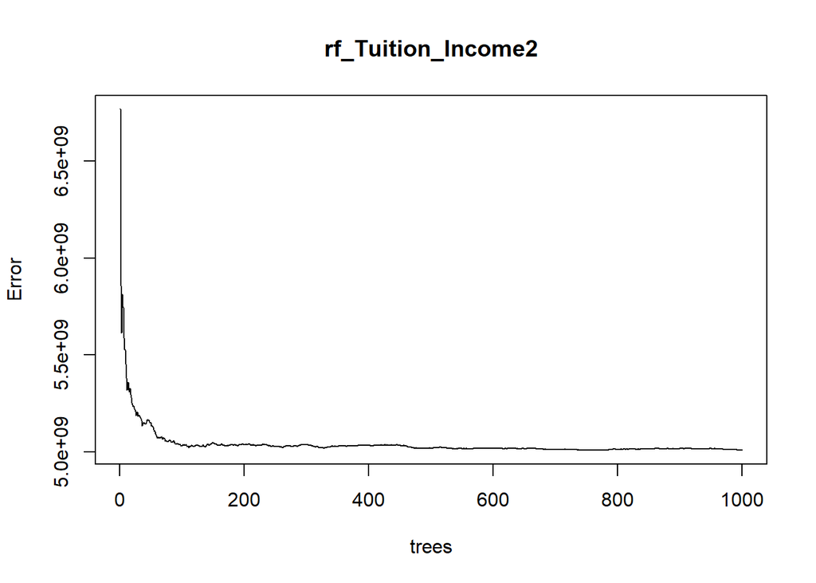

```r
#  r.field.matrix  contains 377 words.
# row names contain name of degrees... I no only need the words but also the Net Income
#FieldofStudy_Earnings_for_rep Contains the original data
#Review if they are align and add Salary_10Y_4Y_Tui

r.field.matrix2 = cbind(r.field.matrix,FieldofStudy_Earnings_for_rep[,c("CIPDESC","Salary_10Y_4Y_Tui")])

#Yes they are aligned. Now we should eliminate words that are already taken into consideration as top ones in the Liner regression and for the model
#those are ones that repeat the most, listed in Word_Fields column word. Word_Field$Word is a factor

Words_inc = levels(Word_Fields$Word)


#Do a random forest calculation first with r.field.matrix.red_nocor.sig , adding fields from r.field.matrix2

#Add columns of words that were not included before
#!(colnames(r.field.matrix) %in% Words_inc)

r.field.matrix.red_nocor.sig2 = cbind(r.field.matrix.red_nocor.sig,r.field.matrix[,!(colnames(r.field.matrix) %in% Words_inc)])


#It looks like they are alinged. Follow the removal of Nas to complete random forest model

r.field.matrix.red_nocor.sig.no.nas2 = r.field.matrix.red_nocor.sig2[!is.na(r.field.matrix.red_nocor.sig2$ADM_RATE)  & !is.na(r.field.matrix.red_nocor.sig2$SAT_AVG),]

rf_Tuition_Income2 = randomForest(Salary_10Y_4Y_Tui ~ . , data=r.field.matrix.red_nocor.sig.no.nas2, mtry=20 ,ntree=1000,importance=TRUE, keep.forest=TRUE)

plot(rf_Tuition_Income2)
```

```r
#It is an improvement for .4 e+09
importance(rf_Tuition_Income2)
```

```
##                               %IncMSE IncNodePurity
## nursing                    20.1470142  9.237396e+12
## management                 27.7256449  3.347247e+12
## administration             19.2664398  5.375107e+12
## services                   26.6467931  2.307850e+12
## studies                    30.4769025  3.006104e+12
## engineering                65.8066973  4.730077e+13
## sciences                   18.1175162  8.072177e+11
## arts                       30.7125110  4.377570e+12
## business                   21.9154316  9.315434e+11
## operations                 14.1089121  6.007434e+11
## health                     16.8908884  3.416008e+11
## related                    19.9454364  1.024023e+12
## research                   16.3242601  4.518866e+12
## psychology                 29.4444471  3.003441e+12
## communication              20.0557321  7.681340e+11
## biology                    30.2752132  2.921486e+12
## computer                   56.2450633  2.193615e+13
## science                    13.2807587  1.875771e+12
## methods                    11.8568442  1.845824e+11
## media                      12.6055582  2.699535e+11
## accounting                 29.4539053  2.707411e+12
## information                37.4401906  7.092230e+12
## marketing                  57.3282861  1.121900e+12
## literature                 20.6351648  9.137741e+11
## applied                    14.5453975  1.720899e+11
## social                     13.2814250  1.710525e+11
## educationfitness           19.6944138  8.543545e+11
## government                  9.9739341  2.779067e+11
## sociology                  27.4567105  7.949464e+11
## humanities                  5.2257331  5.911138e+10
## human                      13.2595270  2.022693e+11
## economics                  68.6949327  2.634041e+12
## resources                  11.9262289  2.676005e+11
## professions                18.4794655  7.217413e+11
## finance                    16.7608326  8.967753e+11
## fine                       17.4266448  1.156248e+12
## history                    31.1524232  9.353576e+11
## mechanical                 26.6626602  7.176427e+12
## work                       10.0151077  9.100323e+10
```

[output cut: 326 more lines]

```
## theory                     -6.7670722  2.537096e+10
## therapeutic                 2.3802310  2.886614e+10
## toxicology                  0.0000000  1.721506e+08
## transportation             19.2195530  2.153590e+11
## treatment                  13.5671428  4.700376e+11
## undergraduate               8.3500754  6.871990e+09
## urban                       6.0037290  7.494215e+09
## vehicle                     6.6152400  8.373199e+09
## veterinary                  0.0000000  0.000000e+00
## visual                      8.6628199  4.490370e+10
## vocational                  0.0000000  9.043562e+10
## vocations                   0.0000000  1.440697e+08
## wildlands                  10.1794670  7.441973e+10
## wildlife                    9.8552891  7.967923e+10
## zoologyanimal              18.5637132  1.029491e+11
```

```r
#check with sample prediction

data.for.prediction = r.field.matrix.red_nocor.sig.no.nas2[sample(c(1:dim(r.field.matrix.red_nocor.sig.no.nas2)[1]),size=50),]

data.for.prediction.result.compare = data.for.prediction$Salary_10Y_4Y_Tui

#remove target variable
data.for.prediction= data.for.prediction[,colnames(data.for.prediction)!="Salary_10Y_4Y_Tui"]

predictions = predict(rf_Tuition_Income,newdata=data.for.prediction)

cbind(predictions,data.for.prediction.result.compare)
```

```
##                                                                                            predictions
## Computer.Science..151                                                                         537435.3
## Computer.Science..42                                                                          530927.7
## Romance.Languages..Literatures..and.Linguistics..112                                          258382.3
## Criminology..17                                                                               263370.6
## Construction.Management..13                                                                   351346.9
## Electrical..Electronics.and.Communications.Engineering..123                                   577121.2
## Education..General..15                                                                        256049.0
## Electrical..Electronics.and.Communications.Engineering..33                                    577244.9
## Multi.Interdisciplinary.Studies..Other.                                                       241629.7
## Political.Science.and.Government..88                                                          251195.0
## Fine.and.Studio.Arts..293                                                                     167987.8
## Area.Studies..37                                                                              284001.8
## Registered.Nursing..Nursing.Administration..Nursing.Research.and.Clinical.Nursing..551        537300.5
## Business.Corporate.Communications..3                                                          257683.5
## Romance.Languages..Literatures..and.Linguistics..14                                           273083.4
## Teacher.Education.and.Professional.Development..Specific.Levels.and.Methods..370              270860.0
## Civil.Engineering..165                                                                        556421.8
## Animal.Sciences..28                                                                           249863.4
## Biology..General..488                                                                         203050.1
## Multi.Interdisciplinary.Studies..Other..88                                                    229261.5
## Psychology..General..661                                                                      201011.5
## Teacher.Education.and.Professional.Development..Specific.Levels.and.Methods..259              270570.8
## Pharmacy..Pharmaceutical.Sciences..and.Administration..7                                      304408.3
## Biology..General..427                                                                         205362.4
## Sociology..151                                                                                223897.6
## Teacher.Education.and.Professional.Development..Specific.Levels.and.Methods..403              271646.5
## Liberal.Arts.and.Sciences..General.Studies.and.Humanities..236                                227100.0
## Communication.and.Media.Studies..195                                                          241070.5
## Marketing..358                                                                                315260.1
## Psychology..General..40                                                                       200971.4
## Linguistic..Comparative..and.Related.Language.Studies.and.Services..4                         227139.2
## Biology..General..27                                                                          201454.6
## Teacher.Education.and.Professional.Development..Specific.Levels.and.Methods..294              277522.2
## Homeland.Security..Law.Enforcement..Firefighting.and.Related.Protective.Services..Other..1    261723.4
## Business.Commerce..General..108                                                               348785.9
## Liberal.Arts.and.Sciences..General.Studies.and.Humanities..264                                225996.8
## Electrical..Electronics.and.Communications.Engineering..111                                   571358.6
## Natural.Resources.Conservation.and.Research..11                                               235936.5
## Metallurgical.Engineering..1                                                                  541515.6
```

[output cut: 47 more lines]

```
## Liberal.Arts.and.Sciences..General.Studies.and.Humanities..264                                                         214888
## Electrical..Electronics.and.Communications.Engineering..111                                                            387412
## Natural.Resources.Conservation.and.Research..11                                                                        220728
## Metallurgical.Engineering..1                                                                                           656180
## Business.Administration..Management.and.Operations..1020                                                               327988
## Business.Commerce..General..181                                                                                        335820
## Biology..General..300                                                                                                  277908
## Public.Administration..10                                                                                              296272
## Teacher.Education.and.Professional.Development..Specific.Subject.Areas..160                                            231684
## English.Language.and.Literature..General..63                                                                           127064
## Health.and.Medical.Administrative.Services..43                                                                         282692
## Geological.and.Earth.Sciences.Geosciences..15                                                                          257792
## Biology..General..341                                                                                                  230964
## Finance.and.Financial.Management.Services..220                                                                         346524
## Rhetoric.and.Composition.Writing.Studies..80                                                                           288980
```

```r
#better predictor, but not very good in to predict for not frequent degress/words like Music. Does better when multiple words are part of major
```